# Conditions & If Statements

Explaining Conditions and giving examples of If Statements in Python programming language.

- Conditions
- If Statements Syntax
- If Statement Example
- If Statement with else clause
- Resources

## Conditions

##### Conditions are used to determine which action to take. Conditional statements return a boolean value (i.e., True or False). We use these statements to control the flow of the program and make it more interactive.

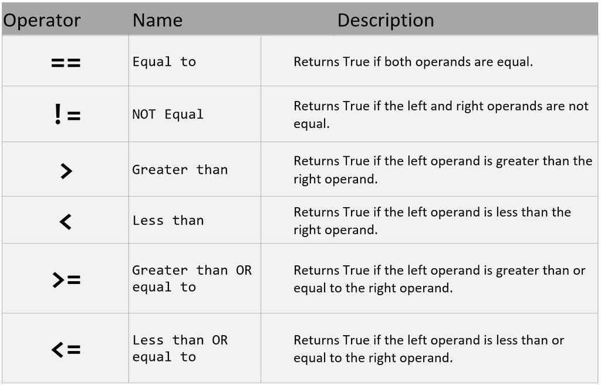

## If Statement Syntax

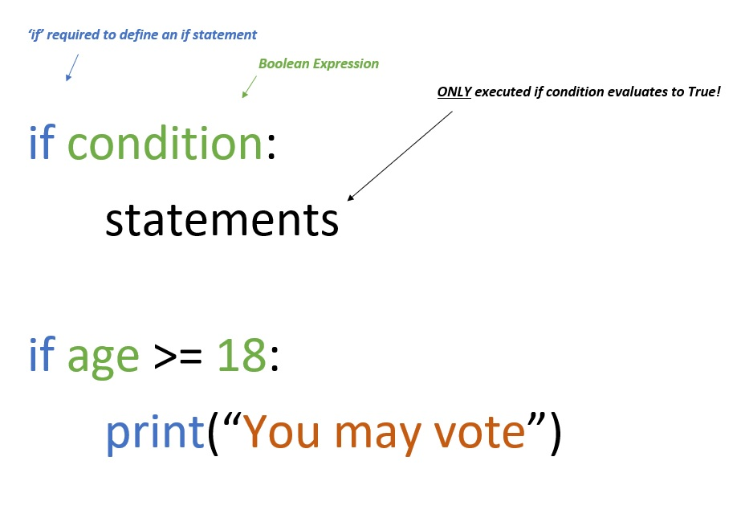

## If Statement Example

#### In the below example we use two variables, a and b, which are used as part of the if statement to test whether a is greater than b. As a is 100, and b is 40, we know that 100 is greater than 40, and so we print to screen that "a is greater than b".

Note: Indentations are required in Python. Indentations are the whitespaces at the beginning of a line and they define the scope of the function.

```python
a = 100
b = 40

if a > b:
  print("a is greater than b")
```

```
a is greater than b
```

### Indentation Errors

Without indentations causes Python to raise an error!

```python
a = 100
b = 40

if a > b:
print("a is greater than b") # you will get an error without proper indentations!
```

```
  File "<ipython-input-2-d046265ffaf2>", line 5
    print("a is greater than b") # you will get an error without proper indentations!
        ^
IndentationError: expected an indented block
```

## If statement with else clause

The else keyword catches the all false results of the conditions.

```python
age = 14

if age >= 18:
    print("You may vote")
else:
    print("You are too young to vote.")
```

```
You are too young to vote.
```

## If statement with elif and else clause

#### In the below example we use the variable age and set the value to 18. The first condition of the if statement tests whether age is greater than or equal to 19. Since it is not, the statement is evaluated to False and is passed to the 'elif" statement. This condition tests to see if age equals 18. It evaluates to true and then executes the print statement.

```python
age = 18

if age >= 19:
    print("You may vote")
elif age == 18:
    print("This is your first year to vote!")
else:
    print("You are too young to vote.")
```

```
This is your first year to vote!
```

## Resources

#### Sources and deeper learning research:

1. Python Programming-Beginner to Pro.Michael Urban,Joel Murach.Murach Press.2016.ISBN:978-1-890774-97-4.www.murach.com.
1. W3Schools.com - [Python If ... Else](https://www.w3schools.com/python/python_conditions.asp)